# Machine Learning Lab

## Lab 4 - Synthetic Data Generation

Shyam Sundaram  
19BCE1560  
August 23, 2021  
Abdul Quadir Md  
L31+L32

```python
import numpy as np
import pandas as pd
```

```python
cities = ['Berlin', 'Frankfurt', 'Hamburg',
          'Nuremberg', 'Munich', 'Stuttgart',
          'Hanover', 'Saarbruecken', 'Cologne',
          'Constance', 'Freiburg', 'Karlsruhe'
         ]

n= len(cities)
data = {'Temperature': np.random.normal(24, 3, n),
        'Humidity': np.random.normal(78, 2.5, n),
        'Wind': np.random.normal(15, 4, n)
       }
df = pd.DataFrame(data=data, index=cities)
print(df)
```

```
              Temperature   Humidity       Wind
Berlin          28.878008  76.374819  19.530793
Frankfurt       26.687688  81.038821  15.653546
Hamburg         22.777766  84.831234  17.370440
Nuremberg       18.924812  75.827156  11.617265
Munich          24.565187  75.281231  22.033213
Stuttgart       24.268067  77.937367  15.135716
Hanover         20.716405  77.921929  16.921148
Saarbruecken    28.447610  75.418671  17.237213
Cologne         22.884340  78.766651  13.715600
Constance       25.991042  79.054356  17.153040
Freiburg        21.076338  76.455803  13.570219
Karlsruhe       22.895551  74.990026  17.862472
```

## Creating dummy DataFrames

```python
import pandas.util.testing as tm
```

```python
np.random.seed()
tm.makeTimeDataFrame()
```

|  | A | B | C | D |
| --- | --- | --- | --- | --- |
| 2000-01-03 | 0.562224 | 1.066494 | 0.198772 | -1.431630 |
| 2000-01-04 | 0.350673 | 0.116160 | 2.271941 | -2.051001 |
| 2000-01-05 | -0.183626 | 0.150777 | 1.266340 | 1.396614 |
| 2000-01-06 | 0.562470 | -1.679381 | -0.397557 | 0.671614 |
| 2000-01-07 | -1.291405 | -2.927531 | -0.254813 | -1.317623 |
| 2000-01-10 | 0.690447 | 0.474442 | -0.774950 | 1.095013 |
| 2000-01-11 | 0.942815 | -0.988008 | 1.956815 | -0.284190 |
| 2000-01-12 | 0.837816 | 1.301068 | -1.647590 | -1.284160 |
| 2000-01-13 | 0.282216 | 0.154308 | -1.366371 | 0.646656 |
| 2000-01-14 | -0.080940 | -0.574532 | 0.619834 | 0.395693 |
| 2000-01-17 | 0.004140 | -0.916735 | -3.083150 | 0.057467 |
| 2000-01-18 | -0.847563 | 0.025342 | -0.497874 | 0.026334 |
| 2000-01-19 | -0.335901 | 0.015468 | 0.167144 | -0.548557 |
| 2000-01-20 | -0.319741 | -0.792328 | -0.058401 | 0.971995 |
| 2000-01-21 | -0.398634 | -1.104531 | 0.794825 | 0.392032 |
| 2000-01-24 | 0.382909 | 2.021870 | 0.026516 | -0.949534 |
| 2000-01-25 | -0.735479 | 0.424599 | -2.440628 | 1.328340 |
| 2000-01-26 | 0.449687 | -0.752185 | 0.607407 | -0.170876 |
| 2000-01-27 | 0.573030 | 1.548613 | 0.374889 | 0.790633 |
| 2000-01-28 | 0.593906 | 0.163049 | 0.581685 | -0.460179 |
| 2000-01-31 | -1.984648 | 0.253438 | 0.648207 | -0.667325 |
| 2000-02-01 | 0.124686 | 0.153612 | -0.307088 | 0.543989 |
| 2000-02-02 | 0.753795 | 1.024325 | 0.317744 | -0.032904 |
| 2000-02-03 | -0.004831 | 1.055416 | 0.052484 | -0.414294 |
| 2000-02-04 | -0.500702 | -0.684846 | -0.360278 | -0.295108 |
| 2000-02-07 | -0.927410 | 0.662098 | 0.208612 | -2.606123 |
| 2000-02-08 | 1.959763 | 0.410373 | 0.454858 | 0.451044 |
| 2000-02-09 | 0.104196 | -0.662406 | 2.134229 | 0.622289 |
| 2000-02-10 | -1.298092 | 0.420183 | 1.015241 | -0.453667 |
| 2000-02-11 | -0.562973 | 0.396576 | 0.312883 | -0.972553 |

```python
tm.makeDataFrame().shape
```

```
(30, 4)
```

```python
tm.makeDataFrame()
```

|  | A | B | C | D |
| --- | --- | --- | --- | --- |
| uP7yTIlXBQ | -0.255966 | 0.868201 | 0.211990 | -0.522447 |
| 0OwED3Fp0g | -0.068979 | 0.653005 | -0.442640 | 0.657064 |
| NCYU6iq2Fc | -0.796738 | 1.303911 | -0.082808 | 0.430720 |
| WA52mHEjPx | -0.031786 | 0.296942 | 0.666614 | 0.816779 |
| FguapLy8wc | 0.732030 | -0.022302 | -2.452670 | -1.014592 |
| tcH8Gpq6BS | -0.276957 | 0.759222 | 0.257500 | 0.497104 |
| 1qkUTioPtW | -0.821414 | 1.166969 | 1.538712 | 0.353904 |
| Gvp3uHDcyz | -1.098052 | -0.593699 | 1.578908 | 0.054195 |
| sgmUEqdFfp | 0.331915 | 0.335162 | -0.424234 | 0.431163 |
| 6DRBO7wUse | 0.486460 | 0.110703 | -0.706443 | -0.339814 |
| 298tnGhiU4 | -1.619722 | 1.303271 | 0.693096 | -0.452383 |
| a5twcRyEmn | -0.903320 | 0.176606 | -0.816382 | 0.649478 |
| yebfgs0XWi | 0.154614 | 0.463340 | -2.517774 | 0.757119 |
| l7ui71dYNk | -0.993819 | -0.469754 | 0.231340 | -0.433788 |
| IpzCFZLSEK | -0.146199 | 2.016260 | 1.090708 | -0.992165 |
| H4Io5b1Zym | -1.147787 | -0.402059 | 1.380032 | -0.047293 |
| xKru8RqEvs | 0.180291 | -0.303524 | 2.901719 | -0.278251 |
| jXwo65YYDf | 2.023774 | -1.787077 | 0.757439 | -0.477030 |
| 4W0b2ddaaN | 0.060408 | -0.437197 | 1.249870 | -1.246284 |
| UI6RGNMjGP | -0.415388 | 0.271806 | -0.632429 | 1.056927 |
| z1LcNh7VHj | 0.296165 | -1.211521 | 1.042700 | -0.813684 |
| bPccyBKz6X | 1.105145 | 0.676298 | 0.513036 | -1.361448 |
| YkeBvebgsb | -1.950677 | 0.541355 | -1.400480 | -0.353282 |
| TRmRkXRRl0 | -0.760983 | -1.081931 | 1.350751 | 0.670921 |
| vqEdOAKPXJ | -0.802249 | -0.420193 | 0.622160 | -0.832749 |
| H9WqlTvbDC | 0.694810 | 0.913795 | -0.930902 | 0.614984 |
| PMQziW9m5j | -1.239702 | -1.988189 | 1.827213 | 0.909426 |
| f9GwWpuE0l | 0.380431 | 1.745045 | 2.433599 | -2.490261 |
| QZH40HyLvc | 1.095936 | 0.362596 | 0.017515 | 0.957894 |
| pVOPnz8pX7 | -2.017354 | 0.443387 | -0.031924 | 0.588961 |

## Attributes of pandas.util.testing

The following are a few methods of the module that begin with the string 'make'.

```python
[method for method in dir(tm) if method.startswith('make')]
```

```
['makeBoolIndex',
 'makeCategoricalIndex',
 'makeCustomDataframe',
 'makeCustomIndex',
 'makeDataFrame',
 'makeDateIndex',
 'makeFloatIndex',
 'makeFloatSeries',
 'makeIntIndex',
 'makeIntervalIndex',
 'makeMissingDataframe',
 'makeMixedDataFrame',
 'makeMultiIndex',
 'makeNumericIndex',
 'makeObjectSeries',
 'makePeriodFrame',
 'makePeriodIndex',
 'makePeriodSeries',
 'makeRangeIndex',
 'makeStringIndex',
 'makeStringSeries',
 'makeTimeDataFrame',
 'makeTimeSeries',
 'makeTimedeltaIndex',
 'makeUIntIndex',
 'makeUnicodeIndex']
```

# SciKit Learn

## make_blobs

sklearn.datasets.make_blobs(n_samples=100, n_features=2, *, centers=None, cluster_std=1.0, center_box=- 10.0, 10.0, shuffle=True, random_state=None, return_centers=False) n_samples : int, optional (default=100) The total number of points equally divided among clusters.

n_features : int, optional (default=2) The number of features for each sample.

centers : int or array of shape [n_centers, n_features], optional (default=3) The number of centers to generate, or the fixed center locations.

cluster_std: float or sequence of floats, optional (default=1.0)

The standard deviation of the clusters.

center_box: pair of floats (min, max), optional (default=(-10.0, 10.0)) The bounding box for each cluster center when centers are generated at random.

shuffle : boolean, optional (default=True)

Shuffle the samples.

random_state : int, RandomState instance or None, optional (default=None)

If int, random_state is the seed used by the random number generator; If RandomState instance, random_state is the random number generator; If None, the random number generator is the RandomState instance used by np.random.

Returns X : array of shape [n_samples, n_features] The generated samples.

y : array of shape [n_samples] The integer labels for cluster membership of each sample.

```python
from sklearn.datasets import make_blobs
```

```python
X, y = make_blobs(n_samples=500, centers=3, n_features=5,random_state=0)
print(X.shape)
```

```
(500, 5)
```

```python
X
```

```
array([[ 1.64249334, -2.88623357,  7.14562083,  8.08185457, -2.42375589],
       [ 5.67123279,  2.95990839,  1.43043105,  8.74919259, -7.35623979],
       [ 1.62959948, -1.23868448,  8.25312336,  8.73581944, -2.01883473],
       ...,
       [ 1.65329689,  4.72784253,  1.56959135,  0.84596642, -0.95984764],
       [ 0.40144104,  4.28303574,  0.906378  ,  2.64805432, -0.3404857 ],
       [ 1.40435103,  3.26399947,  2.3464959 ,  0.89189476, -2.50960369]])
```

```python
y
```

```
array([1, 2, 1, 2, 0, 0, 2, 1, 1, 2, 1, 2, 0, 1, 1, 2, 2, 0, 0, 2, 2, 1,
       0, 0, 0, 2, 2, 0, 0, 1, 2, 2, 1, 0, 1, 0, 1, 2, 1, 0, 2, 1, 2, 2,
       2, 2, 2, 2, 0, 2, 2, 0, 0, 2, 0, 1, 0, 0, 0, 1, 0, 0, 0, 2, 1, 0,
       0, 1, 0, 2, 1, 0, 1, 1, 0, 0, 0, 2, 2, 0, 0, 1, 0, 1, 1, 2, 1, 1,
       0, 1, 2, 2, 2, 2, 2, 1, 0, 0, 2, 0, 0, 2, 0, 1, 0, 0, 2, 1, 1, 0,
       2, 1, 0, 0, 0, 2, 2, 1, 1, 1, 1, 2, 1, 2, 2, 2, 0, 2, 2, 0, 0, 2,
       0, 0, 1, 1, 1, 1, 1, 2, 1, 1, 2, 1, 1, 1, 1, 1, 1, 2, 2, 1, 0, 0,
       1, 2, 1, 1, 1, 0, 2, 2, 1, 0, 0, 0, 2, 0, 2, 1, 0, 2, 0, 0, 1, 1,
       2, 0, 1, 2, 2, 0, 1, 0, 1, 0, 2, 2, 2, 2, 0, 2, 2, 0, 2, 2, 0, 0,
       0, 2, 2, 0, 0, 2, 1, 0, 2, 2, 0, 0, 0, 1, 1, 0, 2, 1, 2, 2, 2, 2,
       1, 0, 1, 1, 2, 2, 1, 1, 1, 0, 0, 1, 2, 1, 1, 2, 2, 0, 0, 1, 0, 2,
       2, 1, 1, 2, 2, 1, 1, 0, 0, 1, 1, 2, 2, 2, 0, 2, 2, 2, 1, 2, 0, 2,
       0, 2, 0, 2, 0, 1, 2, 0, 0, 1, 0, 0, 1, 2, 0, 1, 2, 2, 0, 1, 2, 0,
       1, 2, 2, 1, 0, 1, 0, 2, 1, 0, 1, 0, 0, 2, 2, 1, 0, 0, 2, 2, 0, 0,
       1, 1, 1, 1, 1, 1, 2, 2, 0, 1, 0, 0, 1, 1, 0, 2, 2, 2, 1, 1, 0, 1,
       1, 0, 2, 1, 1, 2, 0, 2, 1, 1, 1, 1, 0, 0, 2, 2, 1, 0, 1, 2, 2, 0,
       1, 0, 0, 1, 1, 2, 2, 0, 1, 2, 2, 0, 2, 2, 2, 1, 2, 0, 2, 2, 1, 1,
       1, 1, 1, 0, 2, 1, 1, 1, 2, 1, 0, 1, 1, 0, 0, 2, 0, 0, 1, 1, 0, 2,
       2, 1, 1, 0, 0, 2, 2, 0, 2, 0, 2, 0, 2, 2, 1, 0, 2, 1, 0, 0, 2, 0,
       0, 1, 0, 0, 2, 0, 0, 1, 2, 1, 1, 0, 0, 1, 2, 1, 0, 0, 0, 2, 0, 2,
       2, 1, 2, 0, 2, 2, 2, 0, 1, 1, 1, 1, 0, 0, 1, 0, 2, 1, 1, 0, 2, 1,
       2, 0, 0, 1, 2, 2, 1, 1, 0, 1, 0, 2, 2, 1, 1, 0, 1, 0, 1, 1, 1, 1,
       2, 1, 1, 2, 0, 1, 1, 2, 0, 2, 0, 2, 0, 0, 0, 0])
```

## With default settings

```python
X,y = make_blobs()
```

```python
print(X)
```

```
[[-10.2050109   -3.93093648]
 [ -9.67938965  -5.9837496 ]
 [  4.46274377  -6.40805477]
 [  2.49101817  -7.8367483 ]
 [  1.68267146  -1.63745591]
 [  4.6039797   -7.34130805]
 [  4.1825859   -8.2918166 ]
 [  5.21033173  -8.216286  ]
 [  3.61706948  -9.16722894]
 [  3.28959607  -0.95550959]
 [ -9.32902283  -4.52573112]
 [ -9.16161071  -7.32639624]
 [-10.0732215   -5.83349824]
 [  2.48097233 -11.48100159]
 [  4.58737309  -7.3584225 ]
 [ -8.84218052  -6.10279712]
 [ -8.52387539  -6.80158952]
 [ -9.87990102  -4.47613841]
 [  2.54716931  -1.79855433]
 [  2.45575634  -9.18705119]
 [-10.19255474  -5.91373365]
 [  2.57063916  -3.30384277]
 [-11.78577835  -4.78264911]
 [  3.97001584  -3.09411117]
 [  2.55503727  -6.77781353]
 [ -9.09087916  -6.54905387]
 [  2.81115921  -9.25115201]
 [  3.18041157  -9.34109111]
 [  1.33119926  -2.24955131]
 [  3.95132117  -8.42873153]
 [  4.25897834  -8.90647175]
 [  2.48717293  -2.84355415]
 [-11.94355989  -5.06851422]
 [-10.87716103  -4.9921379 ]
 [  5.35082175  -8.08862255]
 [  3.72080809  -8.8513735 ]
 [-11.40517227  -6.21131698]
 [  2.4824367   -4.52240954]
 [  2.51668941  -4.46122847]
 [  0.99590885  -3.86913353]
```

[output cut: 45 more lines]

```
 [  4.23296756  -8.00777626]
 [  3.66820038  -3.4873599 ]
 [  2.14852867  -4.49817091]
 [  4.53287779  -4.54853079]
 [ -9.80708046  -5.89044163]
 [  2.07229832  -3.48065774]
 [ -9.65041881  -5.67530009]
 [  3.14668987  -7.51448835]
 [ -9.56037103  -5.16034924]
 [  2.40624674  -9.17849923]
 [  1.71922954  -3.98181919]
 [-11.77006466  -6.57496248]
 [  3.55504592  -7.78137152]
 [  2.73170073  -7.97486172]
 [ -8.88301343  -5.23171651]]
```

```python
print(y)
```

```
[2 2 1 1 0 1 1 1 1 0 2 2 2 1 1 2 2 2 0 1 2 0 2 0 1 2 1 1 0 1 1 0 2 2 1 1 2
 0 0 0 0 2 0 1 0 1 2 1 2 1 1 0 0 1 2 0 2 2 1 0 0 0 0 0 2 0 1 2 2 1 0 0 0 2
 1 0 2 2 1 2 0 0 0 1 2 1 0 0 0 2 0 2 1 2 1 0 2 1 1 2]
```

## Dictionary in python

```python
# Dictionary with three keys
Dictionary1 = {'A': 'america', 'B': 'bombay', 'C': 'chennai'}

# Printing keys of dictionary
print(Dictionary1.keys())

# Creating empty Dictionary
empty_Dict1 = {}

# Printing keys of Empty Dictionary
print(empty_Dict1.keys())
```

```
dict_keys(['A', 'B', 'C'])
dict_keys([])
```

## Loading Datasets from SKLearn

```python
from sklearn.datasets import load_digits
digits = load_digits()
digits.keys()
```

```
dict_keys(['data', 'target', 'frame', 'feature_names', 'target_names', 'images', 'DESCR'])
```

```python
n_samples, n_features = digits.data.shape
print((n_samples, n_features))
```

```
(1797, 64)
```

```python
digits.feature_names
```

```
['pixel_0_0',
 'pixel_0_1',
 'pixel_0_2',
 'pixel_0_3',
 'pixel_0_4',
 'pixel_0_5',
 'pixel_0_6',
 'pixel_0_7',
 'pixel_1_0',
 'pixel_1_1',
 'pixel_1_2',
 'pixel_1_3',
 'pixel_1_4',
 'pixel_1_5',
 'pixel_1_6',
 'pixel_1_7',
 'pixel_2_0',
 'pixel_2_1',
 'pixel_2_2',
 'pixel_2_3',
 'pixel_2_4',
 'pixel_2_5',
 'pixel_2_6',
 'pixel_2_7',
 'pixel_3_0',
 'pixel_3_1',
 'pixel_3_2',
 'pixel_3_3',
 'pixel_3_4',
 'pixel_3_5',
 'pixel_3_6',
 'pixel_3_7',
 'pixel_4_0',
 'pixel_4_1',
 'pixel_4_2',
 'pixel_4_3',
 'pixel_4_4',
 'pixel_4_5',
 'pixel_4_6',
 'pixel_4_7',
```

[output cut: 9 more lines]

```
 'pixel_6_1',
 'pixel_6_2',
 'pixel_6_3',
 'pixel_6_4',
 'pixel_6_5',
 'pixel_6_6',
 'pixel_6_7',
 'pixel_7_0',
 'pixel_7_1',
 'pixel_7_2',
 'pixel_7_3',
 'pixel_7_4',
 'pixel_7_5',
 'pixel_7_6',
 'pixel_7_7']
```

```python
print (digits.DESCR)
```

```
.. _digits_dataset:

Optical recognition of handwritten digits dataset
--------------------------------------------------

**Data Set Characteristics:**

    :Number of Instances: 1797
    :Number of Attributes: 64
    :Attribute Information: 8x8 image of integer pixels in the range 0..16.
    :Missing Attribute Values: None
    :Creator: E. Alpaydin (alpaydin '@' boun.edu.tr)
    :Date: July; 1998

This is a copy of the test set of the UCI ML hand-written digits datasets
https://archive.ics.uci.edu/ml/datasets/Optical+Recognition+of+Handwritten+Digits

The data set contains images of hand-written digits: 10 classes where
each class refers to a digit.

Preprocessing programs made available by NIST were used to extract
normalized bitmaps of handwritten digits from a preprinted form. From a
total of 43 people, 30 contributed to the training set and different 13
to the test set. 32x32 bitmaps are divided into nonoverlapping blocks of
4x4 and the number of on pixels are counted in each block. This generates
an input matrix of 8x8 where each element is an integer in the range
0..16. This reduces dimensionality and gives invariance to small
distortions.

For info on NIST preprocessing routines, see M. D. Garris, J. L. Blue, G.
T. Candela, D. L. Dimmick, J. Geist, P. J. Grother, S. A. Janet, and C.
L. Wilson, NIST Form-Based Handprint Recognition System, NISTIR 5469,
1994.

.. topic:: References

  - C. Kaynak (1995) Methods of Combining Multiple Classifiers and Their
    Applications to Handwritten Digit Recognition, MSc Thesis, Institute of
    Graduate Studies in Science and Engineering, Bogazici University.
  - E. Alpaydin, C. Kaynak (1998) Cascading Classifiers, Kybernetika.
  - Ken Tang and Ponnuthurai N. Suganthan and Xi Yao and A. Kai Qin.
    Linear dimensionalityreduction using relevance weighted LDA. School of
    Electrical and Electronic Engineering Nanyang Technological University.
    2005.
  - Claudio Gentile. A New Approximate Maximal Margin Classification
    Algorithm. NIPS. 2000.
```

```python
from matplotlib import pyplot
from pandas import DataFrame
```

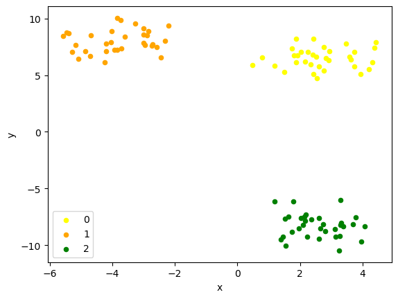

```python
# generate 2d classification dataset
X, y = make_blobs(n_samples=100, centers=3, n_features=2)

# scatter plot, dots colored by class value
df = DataFrame(dict(x=X[:,0], y=X[:,1], label=y))

colors = {0:'yellow', 1:'orange', 2:'green'}

fig, ax = pyplot.subplots()

grouped = df.groupby('label')

for key, group in grouped:
    group.plot(ax=ax, kind='scatter', x='x', y='y', label=key, color=colors[key])
pyplot.show()
```

## make_moons

Make two interleaving half circles.

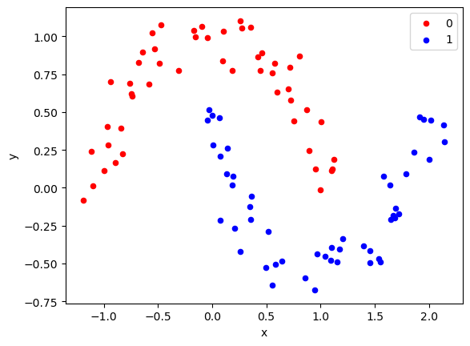

```python
from sklearn.datasets import make_moons

# generate 2d classification dataset
X, y = make_moons(n_samples=100, noise=0.1)

# scatter plot, dots colored by class value
df = DataFrame(dict(x=X[:,0], y=X[:,1], label=y))

colors = {0:'red', 1:'blue'}

fig, ax = pyplot.subplots()

grouped = df.groupby('label')

for key, group in grouped:
    group.plot(ax=ax, kind='scatter', x='x', y='y', label=key, color=colors[key])
pyplot.show()
```

## make_circles

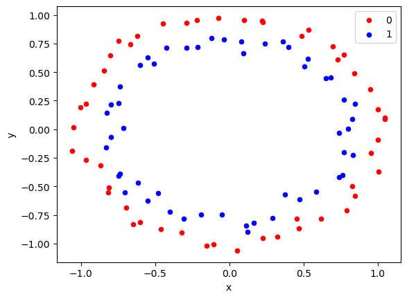

```python
from sklearn.datasets import make_circles


# generate 2d classification dataset
X, y = make_circles(n_samples=100, noise=0.05)

# scatter plot, dots colored by class value
df = DataFrame(dict(x=X[:,0], y=X[:,1], label=y))

colors = {0:'red', 1:'blue'}

fig, ax = pyplot.subplots()

grouped = df.groupby('label')
for key, group in grouped:
    group.plot(ax=ax, kind='scatter', x='x', y='y', label=key, color=colors[key])
pyplot.show()
```

# Classification

## make_classification

Used to generate a random n-class classification problem.

```python
from sklearn.datasets import make_classification
#from sklearn.datasets import make_regression
#from sklearn.datasets import make_blobs
X,y = make_classification (n_samples=100, n_features=6)
X
```

```
array([[-0.5907915 , -0.15165911,  0.26713114, -0.97635134, -0.08756024,
        -1.19726874],
       [ 0.52829382, -0.9848101 , -0.40801511,  0.85307773,  0.08794363,
         1.06910516],
       [-0.45057749, -0.25984875, -0.07712752, -0.72060891, -0.0783719 ,
        -0.91130461],
       [-0.65111453, -0.91756009,  1.58925086, -1.00692244, -0.12985565,
        -1.31429879],
       [ 0.57547467, -2.29894043, -0.10942839, -1.42456046,  1.23168061,
         0.98690222],
       [ 0.40816033, -1.40616875, -0.81378307,  1.24693045, -0.21572888,
         0.87036596],
       [ 0.50755681, -1.29292453,  1.23222148,  0.27617124,  0.34672963,
         0.98611872],
       [ 1.52956249,  0.42431435, -0.58189621, -1.02205311,  1.93973297,
         2.83177026],
       [-0.87442183,  0.86623545,  0.95557068,  1.35442835, -1.48055421,
        -1.56073394],
       [ 0.49411641, -0.24096489, -0.66794806,  1.99617112, -0.49599973,
         1.09039494],
       [-0.44334557, -0.14217127, -0.21097121, -1.15342386,  0.13733048,
        -0.93022272],
       [ 0.0903849 , -0.7998151 ,  1.48088203,  1.76721669, -0.76732615,
         0.30529539],
       [-0.46291821, -0.45659691, -1.16275127,  1.05416371, -0.9464929 ,
        -0.80080241],
       [ 0.47571577, -0.90921646,  1.35738967,  0.5343931 ,  0.19200738,
         0.94505577],
       [ 0.54649873, -0.85037773,  0.98785897,  0.12540579,  0.45631211,
         1.04879766],
       [ 0.30489873,  0.9070041 , -0.51592566, -0.40690962,  0.4847076 ,
         0.54914007],
       [ 0.5537978 ,  0.340965  ,  0.17072063, -0.22063876,  0.63020529,
         1.03655728],
       [-0.33406718, -1.28897763, -0.5776267 ,  2.28953055, -1.42078701,
        -0.46249974],
       [-0.53213845,  1.2189323 ,  0.75613871, -0.23262161, -0.39099242,
        -1.02958066],
       [-0.3938379 ,  0.07952898, -0.21499763, -1.74431665,  0.46929691,
        -0.88067361],
```

[output cut: 145 more lines]

```
        -0.16933455],
       [-0.4313461 , -0.72619273, -0.43280066, -0.33691977, -0.24534108,
        -0.84576693],
       [-0.94111216, -0.20746832,  0.02684217, -1.18852905, -0.31647145,
        -1.87952513],
       [-0.47482899, -1.18020663, -1.00578238, -0.5419553 , -0.18751947,
        -0.94394013],
       [ 0.72722588,  0.28609752, -1.58614117,  0.14986006,  0.61542663,
         1.39435052],
       [-0.11444274,  0.02064306,  0.51507418,  1.13887318, -0.6578145 ,
        -0.13167738],
       [ 0.56781994, -0.26736888, -0.46315604, -0.98565373,  1.01263868,
         1.0054761 ],
       [-0.30778115,  0.91324534,  1.62556752,  1.11441214, -0.82885233,
        -0.50121482]])
```

```python
y
```

```
array([0, 1, 0, 0, 0, 1, 1, 1, 1, 1, 0, 1, 1, 1, 0, 1, 0, 1, 0, 0, 0, 1,
       0, 1, 1, 1, 1, 0, 1, 1, 0, 1, 0, 0, 1, 1, 0, 0, 1, 0, 0, 0, 0, 0,
       1, 1, 0, 0, 0, 0, 0, 1, 0, 0, 1, 1, 0, 0, 1, 0, 1, 1, 0, 1, 0, 0,
       1, 1, 1, 1, 1, 1, 1, 0, 0, 1, 0, 0, 0, 0, 0, 1, 0, 1, 0, 1, 0, 1,
       0, 0, 1, 1, 1, 0, 1, 0, 1, 1, 0, 1])
```

The 'weights' attribute is used to specify many of the samples are to be assigned to each class. If they don't sum up to 1, then more than *n_samples* may be returned.

```python
X,y = make_classification (n_samples=100, n_features=20,
                           n_informative=5,
                           n_redundant=1,
                           n_repeated=1,
                           n_classes=3,
                           n_clusters_per_class=1,
                           hypercube=False,
                           shift=None,scale=None,
                           weights=[0.98, 0.01],
                          random_state=0)
X
```

```
array([[  29.568076  ,  -13.11459595,   58.03334524, ...,   17.72887606,
         -84.18215588,  -54.37669467],
       [  16.49171463,   35.44060746,  129.30115897, ...,   47.62031277,
        -113.08959885,   62.98218632],
       [ -27.04053195,  -18.12537489,  -18.93253963, ...,   -0.34733899,
         -47.47631165,   35.2410516 ],
       ...,
       [ -56.33912532,  -53.84749403,   48.35488233, ...,   11.92611085,
          23.40598401,   73.05101181],
       [ -67.25163471, -112.05338235,  -16.47776853, ...,   40.12837383,
          57.46695192,   95.08465209],
       [ -51.04642793,  -88.59510805,  107.97132999, ...,   35.41039886,
         150.63675375,  122.88711397]])
```

```python
y
```

```
array([0, 0, 0, 0, 0, 0, 0, 0, 0, 0, 0, 0, 0, 0, 0, 0, 0, 0, 1, 0, 0, 0,
       0, 0, 0, 0, 0, 0, 0, 0, 0, 0, 0, 0, 0, 0, 0, 0, 0, 0, 0, 0, 0, 0,
       0, 0, 0, 0, 0, 0, 0, 0, 0, 0, 0, 0, 0, 0, 0, 0, 0, 0, 0, 0, 0, 0,
       0, 0, 0, 0, 0, 0, 0, 0, 0, 0, 0, 0, 0, 0, 0, 0, 0, 0, 0, 0, 0, 2,
       0, 0, 0, 0, 0, 0, 0, 0, 0, 0, 0, 0])
```

```python
X,y = make_classification (n_samples=100, n_features=20,
                           n_informative=5,
                           n_redundant=1,
                           n_repeated=1,
                           n_classes=3, # SUMMER  WINTER AUT
                           n_clusters_per_class=1,
                           hypercube=False,
                           shift=None,scale=None,
                           weights=[0.25, 0.25],
                          random_state=123)
y
```

```
array([1, 0, 0, 2, 2, 0, 0, 1, 0, 2, 2, 2, 2, 2, 2, 1, 0, 2, 2, 1, 0, 1,
       2, 2, 0, 0, 2, 1, 2, 2, 2, 0, 2, 2, 2, 2, 2, 2, 2, 2, 1, 0, 2, 2,
       1, 2, 2, 1, 2, 1, 0, 1, 2, 2, 0, 2, 0, 1, 2, 0, 2, 1, 1, 2, 1, 2,
       2, 2, 2, 2, 0, 2, 2, 1, 0, 2, 1, 2, 2, 2, 2, 1, 1, 1, 2, 0, 1, 0,
       0, 1, 1, 0, 1, 2, 0, 0, 0, 1, 1, 2])
```

```python
X,y = make_classification (n_samples=100, n_features=20,
                           n_informative=5,
                           n_redundant=1,
                           n_repeated=1,
                           n_classes=3,
                           n_clusters_per_class=1,
                           hypercube=False,
                           shift=None,scale=None,
                           weights=[0.50, 0.50],
                          random_state=0)
y
```

```
array([0, 1, 0, 0, 1, 1, 0, 1, 1, 1, 0, 1, 1, 1, 1, 1, 1, 1, 1, 1, 0, 0,
       0, 0, 0, 1, 0, 0, 1, 1, 1, 0, 0, 0, 1, 0, 0, 1, 0, 0, 0, 1, 1, 0,
       0, 1, 0, 0, 1, 0, 1, 0, 0, 1, 1, 1, 0, 0, 1, 0, 1, 1, 1, 1, 1, 1,
       1, 1, 0, 0, 0, 0, 0, 1, 0, 0, 1, 1, 1, 0, 0, 0, 0, 1, 0, 1, 0, 1,
       0, 0, 0, 1, 0, 1, 0, 1, 1, 1, 0, 0])
```

```python
X,y = make_classification (n_samples=100, n_features=20,
                           n_informative=5,
                           n_redundant=1,
                           n_repeated=1,
                           n_classes=3,
                           n_clusters_per_class=1,
                           hypercube=False,
                           shift=None,scale=None,
                           weights=[0.70, 0.20],
                          random_state=12)
y
```

```
array([0, 0, 0, 0, 1, 1, 0, 0, 2, 0, 0, 0, 0, 0, 0, 1, 0, 0, 1, 0, 0, 2,
       0, 1, 0, 2, 0, 1, 0, 1, 0, 2, 0, 1, 0, 0, 0, 1, 0, 1, 1, 1, 0, 0,
       1, 0, 0, 2, 0, 0, 0, 0, 0, 0, 0, 0, 0, 2, 1, 0, 2, 2, 0, 0, 0, 1,
       0, 1, 1, 0, 0, 0, 0, 0, 0, 0, 0, 1, 0, 0, 0, 2, 0, 0, 0, 0, 1, 0,
       0, 0, 1, 0, 0, 0, 0, 1, 0, 0, 0, 0])
```

```python
X,y = make_classification (n_samples=100, n_features=20,
                           n_informative=5,
                           n_redundant=1,
                           n_repeated=1,
                           n_classes=3,
                           n_clusters_per_class=1,
                           hypercube=False,
                           shift=None,scale=None,
                           weights=[0.70, 0.20],
                          random_state=1234)
X
```

```
array([[  -0.423384  ,  -32.75980063,   36.87880291, ...,   82.86298242,
          -6.26783506,   56.87120641],
       [   0.47732816,   49.66628731,  -61.05286006, ...,  190.52379208,
           8.95682073,  124.45123306],
       [  -1.13469587,   19.33704274,  279.4313817 , ...,  121.03684113,
         -35.73142327,   16.22324205],
       ...,
       [  -1.0442674 ,  -81.67468087,  147.58005548, ...,  119.95613397,
         -27.39131745,  -16.88676533],
       [   1.53083844,  -33.90750226,  -86.27709805, ...,   65.33770545,
          -9.61118386,   -7.47588458],
       [   0.34329715, -115.68762902, -121.64996714, ...,  -36.50693796,
           3.33398176,  -85.15825564]])
```

```python
from sklearn.datasets import load_digits
digits = load_digits()
digits.keys()
```

```
dict_keys(['data', 'target', 'frame', 'feature_names', 'target_names', 'images', 'DESCR'])
```

```python
n_samples, n_features = digits.data.shape
print((n_samples, n_features))
```

```
(1797, 64)
```

```python
print(digits.data[0])
```

```
[ 0.  0.  5. 13.  9.  1.  0.  0.  0.  0. 13. 15. 10. 15.  5.  0.  0.  3.
 15.  2.  0. 11.  8.  0.  0.  4. 12.  0.  0.  8.  8.  0.  0.  5.  8.  0.
  0.  9.  8.  0.  0.  4. 11.  0.  1. 12.  7.  0.  0.  2. 14.  5. 10. 12.
  0.  0.  0.  0.  6. 13. 10.  0.  0.  0.]
```

```python
print(digits.target)
```

```
[0 1 2 ... 8 9 8]
```

# Regression

## make_regression

```python
from sklearn.datasets import make_regression
```

```python
# generate regression dataset
X, y = make_regression(n_samples=100, n_features=1, noise=0.1)
print(X)
print(y)
```

```
[[-0.67951981]
 [-2.06985816]
 [ 0.38239466]
 [-0.4533569 ]
 [ 0.14902067]
 [-0.09365402]
 [ 1.63105077]
 [ 1.45506533]
 [-1.26844289]
 [ 0.81299081]
 [ 0.93002555]
 [-0.44488774]
 [ 0.36667893]
 [-0.26539938]
 [-0.31633378]
 [-0.73902369]
 [ 0.02810711]
 [-0.06583796]
 [ 0.2273714 ]
 [-0.21529149]
 [-0.67899707]
 [ 1.97867252]
 [ 0.34130233]
 [ 0.58305598]
 [-0.43006694]
 [-1.61532202]
 [-0.17312166]
 [-1.2950828 ]
 [-0.37587885]
 [-0.61068197]
 [-0.09347909]
 [-0.42680502]
 [ 1.35351936]
 [ 0.14809563]
 [-0.98579952]
 [ 0.05557531]
 [-0.50909893]
 [-0.18853735]
 [ 0.61594221]
 [ 0.67561016]
```

[output cut: 65 more lines]

```
 -151.57404009  -16.23340476 -121.38709958  -35.12460059  -57.24718708
   -8.77577642  -39.99796156  126.81434336   13.90337744  -92.57373728
    5.14356487  -47.62160465  -17.59782999   57.77714835   63.14551171
   11.67287709 -122.14652023   54.19104358  -54.50490547   95.01097345
   50.22301776  158.39755059   10.31145347   19.00119567  -40.44628487
  115.00480664  -85.83816298   -7.69399207   -1.21903973 -218.58469289
  -33.65296409 -136.33969622    2.53115963   11.2659511   -49.11047115
 -117.30028029    1.44567569   38.21668061   31.18815638  -47.19028286
  134.29965062   11.58854094  -61.29258328   83.43919909   69.82948467
   -4.18917526  -91.73580057 -105.55122266 -121.58823645  -20.38435199
   36.31134982  -86.99590692   72.04306537 -103.34246772   76.97932073
  -22.98049167   67.83659842   19.25358721  -62.74942027   11.01322541
 -101.21308609  -28.83593681  -99.18257883   75.79476986    7.01755786
  -18.99494271   86.95322456  -28.51337495  155.37907781    5.26626329
  -51.57240668  -62.46354099 -172.31857295  -12.23090504    7.33020236]
```

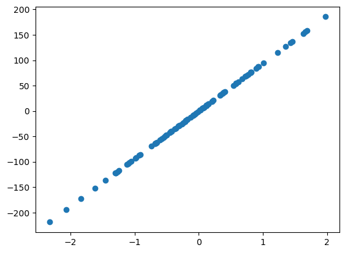

```python
pyplot.scatter(X,y)
pyplot.show()
```

# Exercise Problems

## Question 1

```python
from sklearn.datasets import make_blobs
from pandas import DataFrame
```

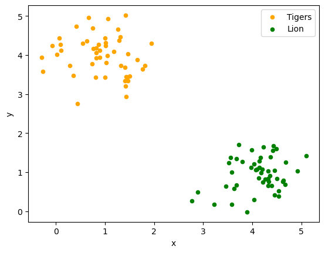

```python
# generate 2d classification dataset
X, y = make_blobs(n_samples=100,  cluster_std=0.5, centers=[(1,4),(4,1)], n_features=2)

# scatter plot, dots colored by class value
df = DataFrame(dict(x=X[:,0], y=X[:,1], label=y))

colors = {0:'orange', 1:'green'}

fig, ax = pyplot.subplots()

grouped = df.groupby('label')

for key, group in grouped:
    group.plot(ax=ax, kind='scatter', x='x', y='y', label=key, color=colors[key])
    pyplot.legend(["Tigers","Lion"])
pyplot.show()
```

## Question 2

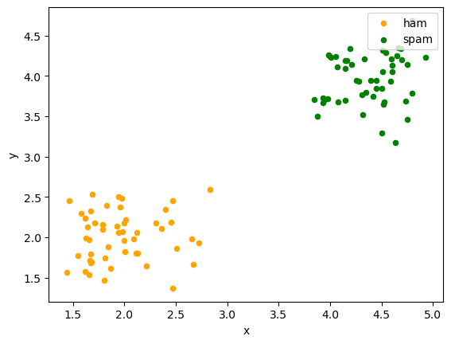

```python
# generate 2d classification dataset
X, y = make_blobs(n_samples=100,  cluster_std=0.3, centers=[(2,2),(4.25,4)], n_features=2)

# scatter plot, dots colored by class value
df = DataFrame(dict(x=X[:,0], y=X[:,1], label=y))

colors = {0:'orange', 1:'green'}

fig, ax = pyplot.subplots()
ax.set_xticks(np.arange(0,5.5,0.5))
grouped = df.groupby('label')

for key, group in grouped:
    group.plot(ax=ax, kind='scatter', x='x', y='y', label=key, color=colors[key])
pyplot.legend(["ham","spam"],loc="upper right")
pyplot.show()
```

## Question 3

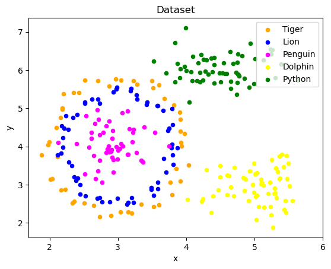

```python
X, y = make_circles(n_samples=(50,60), noise=0.06)

X1,y1 = make_blobs(n_samples=50,centers=([(0,0)]),cluster_std=0.3, n_features=2)
y1=[2 for i in y1]
X=np.concatenate((X, X1))
y=np.concatenate((y, y1))
X=np.array([[i[0]+3,i[1]*1.8+4] for i in X]) #shifting the blobs and circle to 3,4

X1,y1 = make_blobs(n_samples=60,centers=([(5,3)]),cluster_std=0.4, n_features=2)
y1=[3 for i in y1]
X=np.concatenate((X, X1))
y=np.concatenate((y, y1))

X1,y1 = make_blobs(n_samples=60,centers=([(4.5,6)]),cluster_std=0.4, n_features=2)
y1=[4 for i in y1]
X=np.concatenate((X, X1))
y=np.concatenate((y, y1))

df = DataFrame(dict(x=X[:,0], y=X[:,1], label=y))
colors = {0:'orange', 1:'blue', 2:'magenta', 3:'yellow', 4:'green'}
fig, ax = pyplot.subplots()
grouped = df.groupby('label')

for key, group in grouped:
    group.plot(ax=ax, kind='scatter', x='x', y='y', label=['Tiger','Lion','Penguin','Dolphin','Python'][key], color=colors[key])

pyplot.xticks(np.arange(2, 6.5, 1.0))
pyplot.yticks(np.arange(2, 8, 1.0))
pyplot.title("Dataset")
pyplot.legend(loc='upper right')
pyplot.show()
```

## Question 4

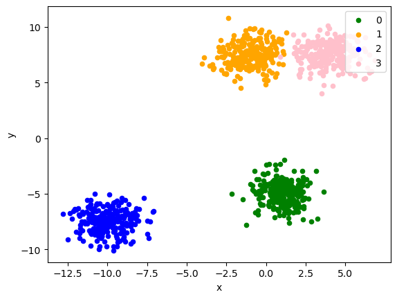

```python
# generate 2d classification dataset
X, y = make_blobs(n_samples=1000,  cluster_std=1, centers=[(1,-5),(-1,7.5),(-10,-7.5),(4,7.5)], n_features=2)

# scatter plot, dots colored by class value
df = DataFrame(dict(x=X[:,0], y=X[:,1], label=y))

colors = {0:'green', 1:'orange',2:'blue',3:'pink'}

fig, ax = pyplot.subplots()
ax.set_xticks(np.arange(-12.5,5.25,2.5))
grouped = df.groupby('label')

for key, group in grouped:
    group.plot(ax=ax, kind='scatter', x='x', y='y', label=key, color=colors[key])
pyplot.legend(["0","1","2","3"],loc="upper right")
pyplot.show()
```

## Question 5

```python
from numpy.random import RandomState
import matplotlib.pyplot as plt

from sklearn.datasets import fetch_olivetti_faces

n_row, n_col = 8, 8
n_components = n_row * n_col
image_shape = (64, 64)

dataset = fetch_olivetti_faces()
faces = dataset.data

n_samples, n_features = faces.shape

def plot_gallery(images, n_col=n_col, n_row=n_row):
    plt.figure(figsize=(2. * n_col, 2.26 * n_row))
    for i, comp in enumerate(images):
        plt.subplot(n_row, n_col, i + 1)
        plt.imshow(comp.reshape(image_shape),cmap='gray',)
        plt.tick_params(left = False, right = False , labelleft = False ,
                labelbottom = False, bottom = False)
    plt.xticks(())
    plt.yticks(())
    plt.subplots_adjust(0.01, 0.05, 0.99, 0.93, 0.04, 0.)
```

```python
plot_gallery(faces[:n_components])
```

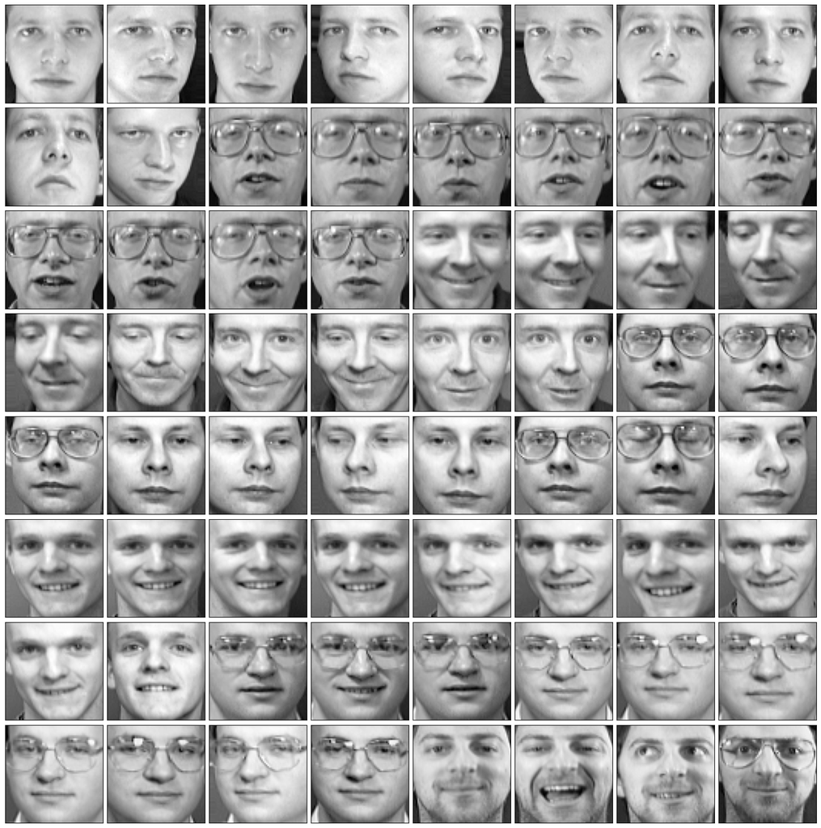

```python
plt.show()
```

## Question 6

```python
from sklearn import datasets
import seaborn as sb
# import some data to play with
iris = datasets.load_iris()
X = iris.data[:, :4]  # we only take the first two features.
y = iris.target
X
```

```
array([[5.1, 3.5, 1.4, 0.2],
       [4.9, 3. , 1.4, 0.2],
       [4.7, 3.2, 1.3, 0.2],
       [4.6, 3.1, 1.5, 0.2],
       [5. , 3.6, 1.4, 0.2],
       [5.4, 3.9, 1.7, 0.4],
       [4.6, 3.4, 1.4, 0.3],
       [5. , 3.4, 1.5, 0.2],
       [4.4, 2.9, 1.4, 0.2],
       [4.9, 3.1, 1.5, 0.1],
       [5.4, 3.7, 1.5, 0.2],
       [4.8, 3.4, 1.6, 0.2],
       [4.8, 3. , 1.4, 0.1],
       [4.3, 3. , 1.1, 0.1],
       [5.8, 4. , 1.2, 0.2],
       [5.7, 4.4, 1.5, 0.4],
       [5.4, 3.9, 1.3, 0.4],
       [5.1, 3.5, 1.4, 0.3],
       [5.7, 3.8, 1.7, 0.3],
       [5.1, 3.8, 1.5, 0.3],
       [5.4, 3.4, 1.7, 0.2],
       [5.1, 3.7, 1.5, 0.4],
       [4.6, 3.6, 1. , 0.2],
       [5.1, 3.3, 1.7, 0.5],
       [4.8, 3.4, 1.9, 0.2],
       [5. , 3. , 1.6, 0.2],
       [5. , 3.4, 1.6, 0.4],
       [5.2, 3.5, 1.5, 0.2],
       [5.2, 3.4, 1.4, 0.2],
       [4.7, 3.2, 1.6, 0.2],
       [4.8, 3.1, 1.6, 0.2],
       [5.4, 3.4, 1.5, 0.4],
       [5.2, 4.1, 1.5, 0.1],
       [5.5, 4.2, 1.4, 0.2],
       [4.9, 3.1, 1.5, 0.2],
       [5. , 3.2, 1.2, 0.2],
       [5.5, 3.5, 1.3, 0.2],
       [4.9, 3.6, 1.4, 0.1],
       [4.4, 3. , 1.3, 0.2],
       [5.1, 3.4, 1.5, 0.2],
```

[output cut: 95 more lines]

```
       [7.7, 3. , 6.1, 2.3],
       [6.3, 3.4, 5.6, 2.4],
       [6.4, 3.1, 5.5, 1.8],
       [6. , 3. , 4.8, 1.8],
       [6.9, 3.1, 5.4, 2.1],
       [6.7, 3.1, 5.6, 2.4],
       [6.9, 3.1, 5.1, 2.3],
       [5.8, 2.7, 5.1, 1.9],
       [6.8, 3.2, 5.9, 2.3],
       [6.7, 3.3, 5.7, 2.5],
       [6.7, 3. , 5.2, 2.3],
       [6.3, 2.5, 5. , 1.9],
       [6.5, 3. , 5.2, 2. ],
       [6.2, 3.4, 5.4, 2.3],
       [5.9, 3. , 5.1, 1.8]])
```

```python
y
```

```
array([0, 0, 0, 0, 0, 0, 0, 0, 0, 0, 0, 0, 0, 0, 0, 0, 0, 0, 0, 0, 0, 0,
       0, 0, 0, 0, 0, 0, 0, 0, 0, 0, 0, 0, 0, 0, 0, 0, 0, 0, 0, 0, 0, 0,
       0, 0, 0, 0, 0, 0, 1, 1, 1, 1, 1, 1, 1, 1, 1, 1, 1, 1, 1, 1, 1, 1,
       1, 1, 1, 1, 1, 1, 1, 1, 1, 1, 1, 1, 1, 1, 1, 1, 1, 1, 1, 1, 1, 1,
       1, 1, 1, 1, 1, 1, 1, 1, 1, 1, 1, 1, 2, 2, 2, 2, 2, 2, 2, 2, 2, 2,
       2, 2, 2, 2, 2, 2, 2, 2, 2, 2, 2, 2, 2, 2, 2, 2, 2, 2, 2, 2, 2, 2,
       2, 2, 2, 2, 2, 2, 2, 2, 2, 2, 2, 2, 2, 2, 2, 2, 2, 2])
```

### Attributes of dataset

```python
iris.keys()
```

```
dict_keys(['data', 'target', 'frame', 'target_names', 'DESCR', 'feature_names', 'filename'])
```

### Full description of dataset

```python
print(iris.DESCR)
```

```
.. _iris_dataset:

Iris plants dataset
--------------------

**Data Set Characteristics:**

    :Number of Instances: 150 (50 in each of three classes)
    :Number of Attributes: 4 numeric, predictive attributes and the class
    :Attribute Information:
        - sepal length in cm
        - sepal width in cm
        - petal length in cm
        - petal width in cm
        - class:
                - Iris-Setosa
                - Iris-Versicolour
                - Iris-Virginica

    :Summary Statistics:

    ============== ==== ==== ======= ===== ====================
                    Min  Max   Mean    SD   Class Correlation
    ============== ==== ==== ======= ===== ====================
    sepal length:   4.3  7.9   5.84   0.83    0.7826
    sepal width:    2.0  4.4   3.05   0.43   -0.4194
    petal length:   1.0  6.9   3.76   1.76    0.9490  (high!)
    petal width:    0.1  2.5   1.20   0.76    0.9565  (high!)
    ============== ==== ==== ======= ===== ====================

    :Missing Attribute Values: None
    :Class Distribution: 33.3% for each of 3 classes.
    :Creator: R.A. Fisher
    :Donor: Michael Marshall (MARSHALL%PLU@io.arc.nasa.gov)
    :Date: July, 1988

The famous Iris database, first used by Sir R.A. Fisher. The dataset is taken
from Fisher's paper. Note that it's the same as in R, but not as in the UCI
Machine Learning Repository, which has two wrong data points.

```

[output cut: 8 more lines]

```

   - Fisher, R.A. "The use of multiple measurements in taxonomic problems"
     Annual Eugenics, 7, Part II, 179-188 (1936); also in "Contributions to
     Mathematical Statistics" (John Wiley, NY, 1950).
   - Duda, R.O., & Hart, P.E. (1973) Pattern Classification and Scene Analysis.
     (Q327.D83) John Wiley & Sons.  ISBN 0-471-22361-1.  See page 218.
   - Dasarathy, B.V. (1980) "Nosing Around the Neighborhood: A New System
     Structure and Classification Rule for Recognition in Partially Exposed
     Environments".  IEEE Transactions on Pattern Analysis and Machine
     Intelligence, Vol. PAMI-2, No. 1, 67-71.
   - Gates, G.W. (1972) "The Reduced Nearest Neighbor Rule".  IEEE Transactions
     on Information Theory, May 1972, 431-433.
   - See also: 1988 MLC Proceedings, 54-64.  Cheeseman et al"s AUTOCLASS II
     conceptual clustering system finds 3 classes in the data.
   - Many, many more ...
```

### Converting to Pandas DataFrame

```python
data1 = pd.DataFrame(data= np.c_[iris['data'], iris['target']],columns= iris['feature_names'] + ['target'])
```

```python
data1
```

|  | sepal length (cm) | sepal width (cm) | petal length (cm) | petal width (cm) | target |
| --- | --- | --- | --- | --- | --- |
| 0 | 5.1 | 3.5 | 1.4 | 0.2 | 0.0 |
| 1 | 4.9 | 3.0 | 1.4 | 0.2 | 0.0 |
| 2 | 4.7 | 3.2 | 1.3 | 0.2 | 0.0 |
| 3 | 4.6 | 3.1 | 1.5 | 0.2 | 0.0 |
| 4 | 5.0 | 3.6 | 1.4 | 0.2 | 0.0 |
| ... | ... | ... | ... | ... | ... |
| 145 | 6.7 | 3.0 | 5.2 | 2.3 | 2.0 |
| 146 | 6.3 | 2.5 | 5.0 | 1.9 | 2.0 |
| 147 | 6.5 | 3.0 | 5.2 | 2.0 | 2.0 |
| 148 | 6.2 | 3.4 | 5.4 | 2.3 | 2.0 |
| 149 | 5.9 | 3.0 | 5.1 | 1.8 | 2.0 |

150 rows × 5 columns

### Adding a column 'Species'

```python
spec={0:'Iris-setosa',1:'Iris-versicolor',2:'Iris-virginica'}
s=np.array([spec[i] for i in data1['target']])
```

```python
data1['Species']=s
data1
```

|  | sepal length (cm) | sepal width (cm) | petal length (cm) | petal width (cm) | target | Species |
| --- | --- | --- | --- | --- | --- | --- |
| 0 | 5.1 | 3.5 | 1.4 | 0.2 | 0.0 | Iris-setosa |
| 1 | 4.9 | 3.0 | 1.4 | 0.2 | 0.0 | Iris-setosa |
| 2 | 4.7 | 3.2 | 1.3 | 0.2 | 0.0 | Iris-setosa |
| 3 | 4.6 | 3.1 | 1.5 | 0.2 | 0.0 | Iris-setosa |
| 4 | 5.0 | 3.6 | 1.4 | 0.2 | 0.0 | Iris-setosa |
| ... | ... | ... | ... | ... | ... | ... |
| 145 | 6.7 | 3.0 | 5.2 | 2.3 | 2.0 | Iris-virginica |
| 146 | 6.3 | 2.5 | 5.0 | 1.9 | 2.0 | Iris-virginica |
| 147 | 6.5 | 3.0 | 5.2 | 2.0 | 2.0 | Iris-virginica |
| 148 | 6.2 | 3.4 | 5.4 | 2.3 | 2.0 | Iris-virginica |
| 149 | 5.9 | 3.0 | 5.1 | 1.8 | 2.0 | Iris-virginica |

150 rows × 6 columns

### Categorical plot

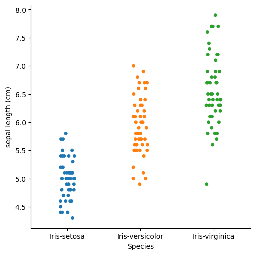

```python
sb.catplot(x="Species",y="sepal length (cm)",data=data1)
plt.show()
```

### Pairplot

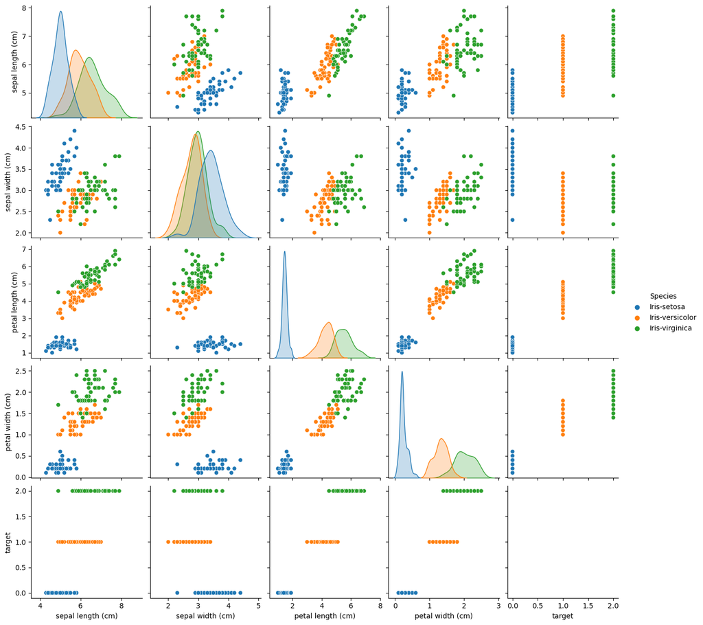

```python
sb.pairplot(data1,hue="Species")
plt.show()
```

### Describing the data

```python
data1.describe()
```

|  | sepal length (cm) | sepal width (cm) | petal length (cm) | petal width (cm) | target |
| --- | --- | --- | --- | --- | --- |
| count | 150.000000 | 150.000000 | 150.000000 | 150.000000 | 150.000000 |
| mean | 5.843333 | 3.057333 | 3.758000 | 1.199333 | 1.000000 |
| std | 0.828066 | 0.435866 | 1.765298 | 0.762238 | 0.819232 |
| min | 4.300000 | 2.000000 | 1.000000 | 0.100000 | 0.000000 |
| 25% | 5.100000 | 2.800000 | 1.600000 | 0.300000 | 0.000000 |
| 50% | 5.800000 | 3.000000 | 4.350000 | 1.300000 | 1.000000 |
| 75% | 6.400000 | 3.300000 | 5.100000 | 1.800000 | 2.000000 |
| max | 7.900000 | 4.400000 | 6.900000 | 2.500000 | 2.000000 |

```python
data1.info()
```

```
<class 'pandas.core.frame.DataFrame'>
RangeIndex: 150 entries, 0 to 149
Data columns (total 6 columns):
 #   Column             Non-Null Count  Dtype
---  ------             --------------  -----
 0   sepal length (cm)  150 non-null    float64
 1   sepal width (cm)   150 non-null    float64
 2   petal length (cm)  150 non-null    float64
 3   petal width (cm)   150 non-null    float64
 4   target             150 non-null    float64
 5   Species            150 non-null    object
dtypes: float64(5), object(1)
memory usage: 7.2+ KB
```